# Clase 1 - Agregados monetarios y API BCRA

Diplomatura Problemas Actuales de la Economía, el Empleo y el Comercio (CEPED FCE - UBA)

DOCENTES:

Ezequiel Monteforte

Juan Camilo Gutman

```r
library(httr)       # para hacer las solicitudes a la API
library(jsonlite)   # para procesar el formato JSON
library(tidyverse)  # nuestro querido tidyverse
library(lubridate)  # para manejar fechas
library(ggthemes)   # para la estética de los gráficos
library(scales)     # para formatear las etiquetas de los gráficos

options(scipen=999) # para evitar la notación científica
```

# Acceso a datos del BCRA via API

En la práctica de hoy vamos a ver cómo acceder a datos del Banco Central de la República Argentina (BCRA) a través de su API.

### ¿Qué es una API?

API es una sigla que viene del inglés (Application Programming Interface) y significa `Interfaz de Programación de Aplicaciones`. Es un intermediario que nos permite comunicarnos con un sistema complejo sin necesidad de conocer todos los detalles de cómo funciona por dentro. Nosotros hacemos una “solicitud” (en inglés, request), y la API nos devuelve una “respuesta” (en inglés, response).

En resumen, una API es un conjunto de reglas y herramientas que permite que diferentes aplicaciones de software se comuniquen entre sí. Simplifica el acceso a datos y funcionalidades de otros sistemas de una manera estandarizada y segura.

#### Los datos y la web

Para trabajar con datos de la web, es fundamental entender cómo se comunican los programas entre sí. Acá es donde entran las **APIs** , que actúan como puentes que permiten que una aplicación solicite información de otra de manera estandarizada.

Al hacer una solicitud a una API nuestra aplicación envía una solicitud a un servidor. Si todo sale bien, el servidor nos devuelve los datos con un código de estado `200`, que es el “lenguaje” del servidor para decir “recibí tu solicitud y la pude completar con éxito”. En cambio, si pedimos a un servidor algo que no existe entonces recibiremos como respuesta el famoso código de estado `404`, el cual ya es parte de la cultura general del internet.

Sin embargo, no solo importa recibir los datos, sino también la seguridad de la conexión. Para esto existen cosas como el protocolo **SSL**. Su propósito es asegurar la **autenticación** (que sepamos que nos estamos comunicando con el servidor real) y la **encriptación** (para que la comunicación sea privada y no pueda ser leída por terceros).

Todo esto para que sepan que nos vamos a ver forzados a desactivar la verificación, perdiendo la garantía de que estamos conectados a la fuente legítima y de que los datos no han sido alterados en el camino…

## API del Banco Central de la República Argentina (BCRA)

El BCRA tiene varias APIs. A nosotros nos interesa la de `Estadísticas Monetarias`, cuyo manual está disponible en [Manual de API de Estadísticas monetarias](https://www.bcra.gob.ar/Catalogo/Content/files/pdf/principales-variables-v3.pdf)

En nuestro caso, nosotros vamos a realizarle solicitudes a la API del BCRA desde R (“dame los datos de las reservas internacionales”), y la API nos los va responder con un código de estado y los datos en un formato ordenado (JSON, que es una especie de diccionario muy utilizado), entre otras cosas que no nos interesan.

### Series disponibles

Primero, vamos a ver qué series de datos están disponibles.

```r
url <- "https://api.bcra.gob.ar/estadisticas/v3.0/monetarias"

# Con la función GET del paquete httr realizamos la solicitud
response <- GET(url, config(ssl_verifypeer = FALSE))

# No se asusten con el JSON, simplemente es un diccionario
data <- fromJSON(content(response, "text"))

df <- data$results %>%
  filter(categoria == 'Principales Variables')

df
```

Series Monetarias Disponibles en la API del BCRA

Variables con su descripción, ID, fecha de dato más reciente y último valor

| ID | Descripción de la Serie | categoria | fecha | valor |
| --- | --- | --- | --- | --- |
| 1 | Reservas Internacionales del BCRA (en millones de dólares - cifras provisorias sujetas a cambio de valuación) | Principales Variables | 2025-06-27 | 41460.0000 |
| 4 | Tipo de Cambio Minorista ($ por USD) Comunicación B 9791 - Promedio vendedor | Principales Variables | 2025-07-01 | 1237.1800 |
| 5 | Tipo de Cambio Mayorista ($ por USD) Comunicación A 3500 - Referencia | Principales Variables | 2025-07-01 | 1203.0000 |
| 6 | Tasa de Política Monetaria (en % n.a.) | Principales Variables | 2025-07-01 | 29.0000 |
| 7 | BADLAR en pesos de bancos privados (en % n.a.) | Principales Variables | 2025-06-30 | 32.0000 |
| 8 | TM20 en pesos de bancos privados (en % n.a.) | Principales Variables | 2025-06-30 | 32.6250 |
| 9 | Tasas de interés de las operaciones de pase activas para el BCRA, a 1 día de plazo (en % n.a.) | Principales Variables | 2025-07-01 | 33.0000 |
| 10 | Tasas de interés de las operaciones de pase pasivas para el BCRA, a 1 día de plazo (en % n.a.) | Principales Variables | 2024-07-19 | 40.0000 |
| 11 | Tasas de interés por préstamos entre entidades financiera privadas (BAIBAR) (en % n.a.) | Principales Variables | 2025-06-30 | 31.5900 |
| 12 | Tasas de interés por depósitos a 30 días de plazo en entidades financieras (en % n.a.) | Principales Variables | 2025-06-30 | 31.4200 |
| 13 | Tasa de interés de préstamos por adelantos en cuenta corriente | Principales Variables | 2025-06-30 | 38.1600 |
| 14 | Tasa de interés de préstamos personales | Principales Variables | 2025-06-30 | 72.5500 |
| 15 | Base monetaria - Total (en millones de pesos) | Principales Variables | 2025-06-27 | 35542364.0000 |
| 16 | Circulación monetaria (en millones de pesos) | Principales Variables | 2025-06-27 | 22894665.0000 |
| 17 | Billetes y monedas en poder del público (en millones de pesos) | Principales Variables | 2025-06-27 | 20742716.0000 |
| 18 | Efectivo en entidades financieras (en millones de pesos) | Principales Variables | 2025-06-27 | 2151949.0000 |
| 19 | Depósitos de los bancos en cta. cte. en pesos en el BCRA (en millones de pesos) | Principales Variables | 2025-06-27 | 12647699.0000 |
| 21 | Depósitos en efectivo en las entidades financieras - Total (en millones de pesos) | Principales Variables | 2025-06-27 | 166890785.0000 |
| 22 | En cuentas corrientes (neto de utilización FUCO) (en millones de pesos) | Principales Variables | 2025-06-27 | 27921754.0000 |
| 23 | En Caja de ahorros (en millones de pesos) | Principales Variables | 2025-06-27 | 59463383.0000 |
| 24 | A plazo (incluye inversiones y excluye CEDROS) (en millones de pesos) | Principales Variables | 2025-06-27 | 69544788.0000 |
| 25 | M2 privado, promedio móvil de 30 días, variación interanual (en %) | Principales Variables | 2025-06-27 | 12.6000 |
| 26 | Préstamos de las entidades financieras al sector privado (en millones de pesos) | Principales Variables | 2025-06-27 | 94744173.0000 |
| 27 | Inflación mensual (variación en %) | Principales Variables | 2025-05-31 | 1.5000 |
| 28 | Inflación interanual (variación en % i.a.) | Principales Variables | 2025-05-31 | 43.5000 |
| 29 | Inflación esperada - REM próximos 12 meses - MEDIANA (variación en % i.a) | Principales Variables | 2025-05-31 | 20.9000 |
| 30 | CER (Base 2.2.2002=1) | Principales Variables | 2025-07-01 | 602.2376 |
| 31 | Unidad de Valor Adquisitivo (UVA) (en pesos -con dos decimales-, base 31.3.2016=14.05) | Principales Variables | 2025-07-01 | 1520.0900 |
| 32 | Unidad de Vivienda (UVI) (en pesos -con dos decimales-, base 31.3.2016=14.05) | Principales Variables | 2025-07-01 | 1110.8500 |
| 34 | Tasa de Política Monetaria (en % e.a.) | Principales Variables | 2025-07-01 | 33.6300 |
| 35 | BADLAR en pesos de bancos privados (en % e.a.) | Principales Variables | 2025-06-30 | 37.1100 |
| 40 | Índice para Contratos de Locación (ICL-Ley 27.551, con dos decimales, base 30.6.20=1) | Principales Variables | 2025-07-01 | 26.0300 |
| 41 | Tasas de interés de las operaciones de pase pasivas para el BCRA, a 1 día de plazo (en % e.a.) | Principales Variables | 2024-07-19 | 49.1500 |
| 42 | Pases pasivos para el BCRA - Saldos (en millones de pesos) | Principales Variables | 2025-06-27 | 0.0000 |
| 43 | Tasa de interés para uso de la Justicia – Comunicado P 14290 \| Base 01/04/1991 (en %) | Principales Variables | 2025-07-01 | 20239.9624 |
| 44 | TAMAR en pesos de bancos privados (en % n.a.) | Principales Variables | 2025-06-30 | 33.6250 |
| 45 | TAMAR en pesos de bancos privados (en % e.a.) | Principales Variables | 2025-06-30 | 39.2900 |

Podemos, por ejemplo, graficar la base monetaria

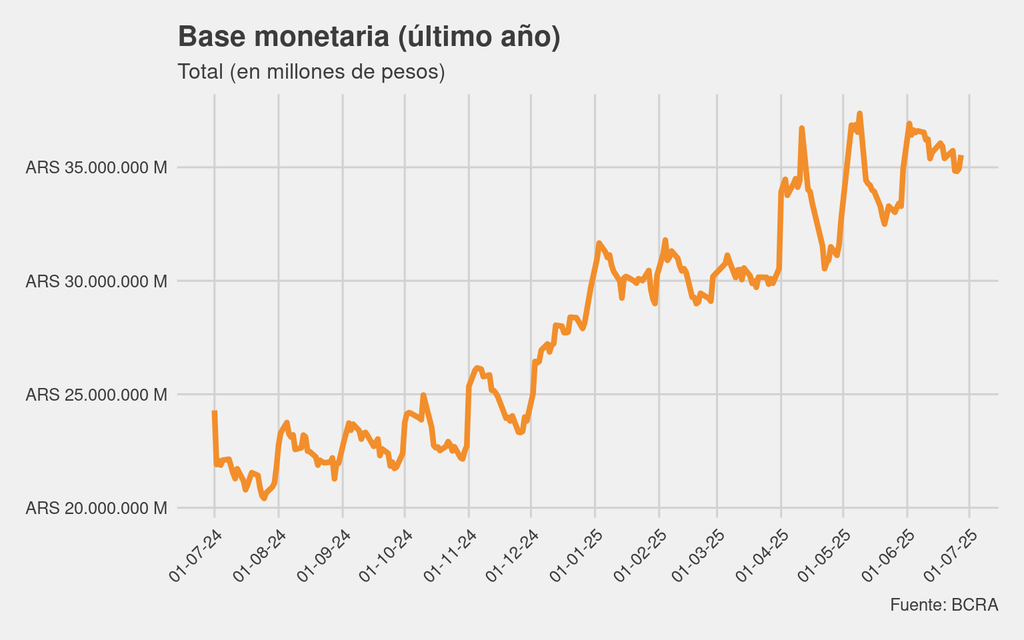

```r
url_base_mon = "https://api.bcra.gob.ar/estadisticas/v3.0/monetarias/15"

response_base_mon <- GET(url_base_mon, config(ssl_verifypeer = FALSE))

data_base_mon <- fromJSON(content(response_base_mon, "text"))

df_base_mon <- data_base_mon$results
df_base_mon$fecha <- as.Date(df_base_mon$fecha)

df_base_mon <- df_base_mon %>%
  filter(fecha >= as.Date("2024-06-30")) %>%
  arrange(fecha) %>%
  select(fecha, valor)

ggplot(df_base_mon, aes(x = fecha, y = valor)) +
  geom_line(color = "#F28E2B", size = 1.5) +
  theme_fivethirtyeight() +
  labs(
    title = "Base monetaria (último año)",
    subtitle = "Total (en millones de pesos)",
    caption = "Fuente: BCRA"
  ) +
  scale_y_continuous(labels = scales::label_dollar(
    prefix = "ARS ",
    suffix = " M",
    big.mark = ".",
    decimal.mark = ","
      ),
    breaks = scales::pretty_breaks(n = 6)
  ) +
  scale_x_date(
    date_labels = "%d-%m-%y",
    date_breaks = "1 month"
  ) +

  theme_fivethirtyeight()+

  theme(
    axis.text.x = element_text(angle = 45, hjust = 1, vjust = 1),
    plot.title = element_text(size = 16, face = "bold"),
    plot.subtitle = element_text(size = 12),
    axis.title.x = element_blank(),
    axis.title.y = element_blank()
  )
```

## Reservas Internacionales

Ahora, vamos a descargar y graficar los datos de las reservas internacionales. La url es la misma de antes pero termina en `/1`, porque esa es la ID de las Reservas Internacionales del BCRA.

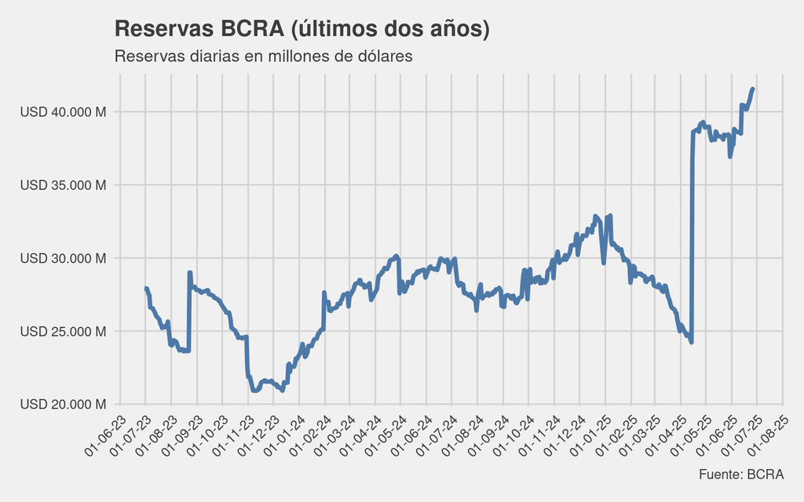

```r
url_reservas = "https://api.bcra.gob.ar/estadisticas/v3.0/monetarias/1"

response_reservas <- GET(url_reservas, config(ssl_verifypeer = FALSE))

data_reservas <- fromJSON(content(response_reservas, "text"))

df_reservas <- data_reservas$results
df_reservas$fecha <- as.Date(df_reservas$fecha)

df_reservas <- df_reservas %>%
  filter(fecha >= as.Date("2023-06-30")) %>%
  arrange(fecha) %>%
  select(fecha, valor)

ggplot(df_reservas, aes(x = fecha, y = valor)) +
  geom_line(color = "#4E79A7", size = 1.5) +
  theme_fivethirtyeight() +
  labs(
    title = "Reservas BCRA (últimos dos años)",
    subtitle = "Reservas diarias en millones de dólares",
    caption = "Fuente: BCRA"
  ) +
  scale_y_continuous(labels = scales::label_dollar(
    prefix = "USD ",
    suffix = " M",
    big.mark = ".",
    decimal.mark = ","
      ),
    breaks = scales::pretty_breaks(n = 6)
  ) +
  scale_x_date(
    date_labels = "%d-%m-%y",
    date_breaks = "1 month"
  ) +
  theme(
    axis.text.x = element_text(angle = 45, hjust = 1, vjust = 1),
    plot.title = element_text(size = 16, face = "bold"),
    plot.subtitle = element_text(size = 12),
    axis.title.x = element_blank(),
    axis.title.y = element_blank()
  )
```

## Circulación monetaria y Reservas

Combinemos varias series disponibles en la API para graficar la circulación monetaria en dólares junto con la serie de reservas que ya descargamos.

```r
url_circulacion = "https://api.bcra.gob.ar/estadisticas/v3.0/monetarias/16"

response_circulacion <- GET(url_circulacion, config(ssl_verifypeer = FALSE))

data_circulacion <- fromJSON(content(response_circulacion, "text"))

df_circulacion <- data_circulacion$results
df_circulacion$fecha <- as.Date(df_circulacion$fecha)

df_circulacion <- df_circulacion %>%
  filter(fecha >= as.Date("2023-06-30")) %>%
  arrange(fecha) %>%
  select(fecha, circulacion = valor)

url_tc = "https://api.bcra.gob.ar/estadisticas/v3.0/monetarias/5"

response_tc <- GET(url_tc, config(ssl_verifypeer = FALSE))

data_tc <- fromJSON(content(response_tc, "text"))

df_tc <- data_tc$results
df_tc$fecha <- as.Date(df_tc$fecha)

df_tc <- df_tc %>%
  filter(fecha >= as.Date("2023-06-30")) %>%
  arrange(fecha) %>%
  select(fecha, tc_mayorista = valor)

df_circ_tc <- left_join(df_circulacion, df_tc, by = "fecha")

df_circ_tc <- df_circ_tc %>%
  mutate(circulacion_dolares = circulacion / tc_mayorista)

# Renombramos la columna valor de df_reservas para el join
df_reservas_renamed <- df_reservas %>%
  rename(reservas = valor)

# Unimos los dos dataframes
df_plot <- left_join(df_circ_tc, df_reservas_renamed, by = "fecha")

# Pasamos a formato long para ggplot
df_plot_long <- df_plot %>%
  select(fecha, `Circulación Monetaria` = circulacion_dolares, `Reservas` = reservas) %>%
  pivot_longer(cols = -fecha, names_to = "variable", values_to = "valor")
```

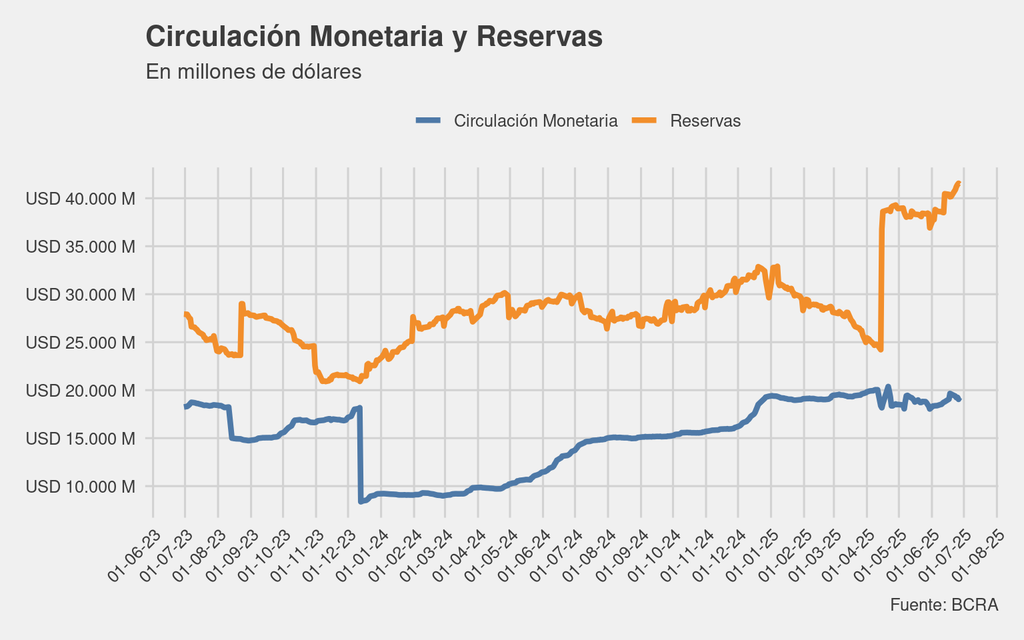

```r
ggplot(df_plot_long, aes(x = fecha, y = valor, color = variable)) +
  geom_line(size = 1.5) +
  theme_fivethirtyeight() +
  labs(
    title = "Circulación Monetaria y Reservas",
    subtitle = "En millones de dólares",
    caption = "Fuente: BCRA",
    color = ""
  ) +
  scale_y_continuous(
    labels = scales::label_dollar(
      prefix = "USD ",
      suffix = " M",
      big.mark = ".",
      decimal.mark = ","
      ),
    breaks = scales::pretty_breaks(n = 6)
  ) +
  scale_x_date(
    date_labels = "%d-%m-%y",
    date_breaks = "1 month"
  ) +
  theme(
    axis.text.x = element_text(angle = 45, hjust = 1, vjust = 1),
    plot.title = element_text(size = 16, face = "bold"),
    plot.subtitle = element_text(size = 12),
    axis.title.x = element_blank(),
    axis.title.y = element_blank(),
    legend.position = "top"
  ) +
  scale_color_manual(values = c("Circulación Monetaria" = "#4E79A7", "Reservas" = "#F28E2B"))
```

## Extra: programación funcional

Solo para quienes quieran ir un poco más allá, algo que no llegamos a ver en la diplomatura y que es extremadamente útil para procesamientos complejos es lo que se conoce como `programación funcional`. Se trata de un enfoque que consiste en construir funciones para reproducir comportamientos, mejorando la legibilidad, asegurando la funcionalidad esperada y eliminando código redundante.

En internet hay muchísimo material para aprender a utilizar funciones en R.

```r
api_bcra <- function(id) {

  # Librerías necesarias
  library(httr)
  library(jsonlite)
  library(lubridate)

  # 1. Se construye la URL con el id provisto
  url <- paste0("https://api.bcra.gob.ar/estadisticas/v3.0/monetarias/", id)

  # 2. Solicitud GET a la API
  response <- GET(url, config(ssl_verifypeer = FALSE))

  # 3. Chequeo de código de estado
  if (status_code(response) != 200) {
    stop("La solicitud falló con código: ", status_code(response))
   }

  # 4. Extraemos los datos del JSON
  data <- fromJSON(content(response, "text"))

  # 5. Creamos el dataframe
  df <- data$results
  df$fecha <- as.Date(df$fecha)

  # 6. Estudien sobre programación funcional para entender qué hace el return
  return(df)
}
```

# Ahora, por ejemplo, así de fácil es pedir las reservas:

```r
prueba_función <- api_bcra(1)

head(prueba_función)
```

```
  idVariable      fecha valor
1          1 2025-06-27 41460
2          1 2025-06-26 41555
3          1 2025-06-25 41417
4          1 2025-06-24 41212
5          1 2025-06-23 40894
6          1 2025-06-19 40182
```

[Diplomatura Problemas Actuales de la Economía, el Empleo y el Comercio](https://ceped-fce-uba.github.io/diplomatura_economia/)

*diplo.problemas.economia@gmail.com*